[figure not shown]

# $\color{darkblue}{\textbf{Databases}}$

### $\color{dodgerblue}{\textbf{Connection}}$

[figure not shown]

### $\color{dodgerblue}{\textbf{Relational Tables}}$

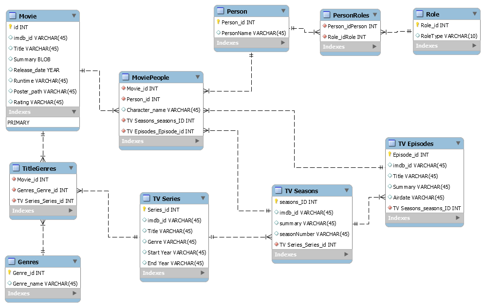

# $\color{darkblue}{\textbf{Working with a Database}}$

### $\color{dodgerblue}{\textbf{R}}$

```r
library(tidyverse)
library(DBI)
library(RMySQL)
```

#### $\color{skyblue}{\textrm{- Create Connection}}$

```r
con <- dbConnect(RMySQL::MySQL(),
                 host = "courses.csrrinzqubik.us-east-1.rds.amazonaws.com",
                 dbname = "tweater",
                 user = "student",
                 port = 3306,
                 password = getPass::getPass("Database Password"))
```

#### $\color{skyblue}{\textrm{- List Tables}}$

```r
dbListTables(con)
```

```
## [1] "comments" "tweats"   "users"
```

#### $\color{skyblue}{\textrm{- Read in Table}}$

```r
df <- dbReadTable(con,"users") %>%
  as_tibble()

head(df)
```

| id | name | login |
| --- | --- | --- |
| 1 | elisabeth | elismith |
| 2 | mike | mikey |
| 3 | thea | teatime |
| 4 | thomas | tomatotom |
| 5 | oliver | olivander |
| 6 | kate | katebenn |

#### $\color{skyblue}{\textrm{- Read in SQL Query}}$

```r
df <-  dbGetQuery(con,

  "SELECT *
     FROM comments
    WHERE user_id = 1"

  ) %>% as_tibble()

head(df)
```

| id | tweat_id | user_id | message |
| --- | --- | --- | --- |
| 1012 | 87 | 1 | awesome! thanks! |
| 1004 | 49 | 1 | this is fabulous! |
| 1020 | 77 | 1 | couldn’t be better |
| 1014 | 77 | 1 | saved my day |

#### $\color{skyblue}{\textrm{- Disconnect}}$

```r
dbDisconnect(con)
```

### $\color{dodgerblue}{\textbf{Python}}$

```python
import pandas as pd
from sqlalchemy import create_engine
```

#### $\color{skyblue}{\textrm{- Create Connection}}$

```python
engine = create_engine("sqlite:///Chinook.sqlite")
```

#### $\color{skyblue}{\textrm{- List Tables}}$

```python
engine.table_names()
```

```
## ['Album', 'Artist', 'Customer', 'Employee', 'Genre', 'Invoice', 'InvoiceLine', 'MediaType', 'Playlist', 'PlaylistTrack', 'Track']
```

#### $\color{skyblue}{\textrm{- Read in SQL Query}}$

```python
df = pd.read_sql_query("SELECT * FROM Album", engine)

df.head()
```

```
##    AlbumId                                  Title  ArtistId
## 0        1  For Those About To Rock We Salute You         1
## 1        2                      Balls to the Wall         2
## 2        3                      Restless and Wild         2
## 3        4                      Let There Be Rock         1
## 4        5                               Big Ones         3
```

# $\color{darkblue}{\textbf{Working with a Table}}$

### $\color{dodgerblue}{\textbf{Shape}}$

#### $\color{skyblue}{\textrm{- Rows}}$

```r
SELECT COUNT(*)
  FROM table;
```

#### $\color{skyblue}{\textrm{- Columns}}$

```r
SELECT *
  FROM table
 LIMIT 1;
```

### $\color{dodgerblue}{\textbf{Missing Values}}$

```r
SELECT COUNT(*) - COUNT(column1) AS column1_missing,
       COUNT(*) - COUNT(column2) AS column2_missing
  FROM table;
```

Other considerations:

- Are there error codes (bunched observations at a specific value, 9, 99, -99)
- Are there missing codes showing up as text (NA, NaN, N/A, #NA)
- Is 0 really 0 or a missing code

### $\color{dodgerblue}{\textbf{Numeric Columns}}$

#### $\color{skyblue}{\textrm{- Basic Summary Stats}}$

```r
SELECT AVG(column) AS avg_column,
       MAX(column) AS max_column,
       MIN(column) AS min_column,
       MAX(column) - MIN(column) AS range_column,
       STDDEV(column) AS std_dev_column
  FROM table
 WHERE column IS NOT NULL;
```

| avg_column | max_column | min_column | range_column | std_dev_column |
| --- | --- | --- | --- | --- |
| 5.5 | 10 | 1 | 9 | 3.02765 |

#### $\color{skyblue}{\textrm{- Percentiles}}$

```r
SELECT PERCENTILE_DISC(0.25) WITHIN GROUP (ORDER BY column) AS perc_25,
       PERCENTILE_DISC(0.5) WITHIN GROUP (ORDER BY column) AS median,
       PERCENTILE_DISC(0.75) WITHIN GROUP (ORDER BY column) AS perc_75
  FROM table;
```

| perc_25 | median | perc_75 |
| --- | --- | --- |
| 3.25 | 5.5 | 7.75 |

#### $\color{skyblue}{\textrm{- Frequency Table}}$

```r
WITH bins AS (
  SELECT GENERATE_SERIES(30, 60, 5) AS lower,
         GENERATE_SERIES(35, 60, 5) AS upper)

   SELECT lower, upper, COUNT(column)
     FROM bins
LEFT JOIN table
          ON column >= lower
          AND column < upper
 GROUP BY lower, upper
 ORDER BY lower;
```

[output not shown]

#### $\color{skyblue}{\textrm{- Correlation}}$

```r
SELECT CORR(column1, column2) AS corr_column1_column2
  FROM table;
```

| corr_column1_column2 |
| --- |
| 0.02 |

```r
DROP TABLE IF EXISTS correlations;

CREATE TEMP TABLE correlations AS
SELECT 'column1'::varchar AS measure,
       corr(column1, column1) AS column1,
       corr(column1, column2) AS column2,
       corr(column1, column3) AS column3
  FROM table;

INSERT INTO correlations
SELECT 'column2'::varchar AS measure,
       corr(column2, column1) AS column1,
       corr(column2, column2) AS column2,
       corr(column2, column3) AS column3
  FROM table;

INSERT INTO correlations
SELECT 'column3'::varchar AS measure,
       corr(column3, column1) AS column1,
       corr(column3, column2) AS column2,
       corr(column3, column3) AS column3
  FROM table;

SELECT measure,
       round(column1::numeric, 2) AS column1,
       round(column2::numeric, 2) AS column2,
       round(column3::numeric, 2) AS column3
  FROM correlations;
```

| measure | column1 | column2 | column3 |
| --- | --- | --- | --- |
| column1 | 1.00 | 0.02 | 0.02 |
| column2 | 0.02 | 1.00 | -0.09 |
| column3 | 0.02 | -0.09 | 1.00 |

### $\color{dodgerblue}{\textbf{Character Columns}}$

#### $\color{skyblue}{\textrm{- Errors}}$

```r
  SELECT category, COUNT(*)
    FROM table
GROUP BY category
ORDER BY count DESC;
```

| category | count |
| --- | --- |
| Apple | 4 |
| banana | 3 |
| apple | 2 |
| Banana | 1 |
| apple | 1 |

What to look for:

- Case mismatch
- Extra spaces
- Spelling errors
- Punctuation (- vs – vs — vs)

```r
  SELECT LOWER(category), COUNT(*)
    FROM table
GROUP BY category
ORDER BY count DESC;
```

| category | count |
| --- | --- |
| apple | 6 |
| banana | 4 |
| apple | 1 |

```r
  SELECT TRIM(category), COUNT(*)
    FROM table
GROUP BY category
ORDER BY count DESC;
```

| category | count |
| --- | --- |
| Apple | 4 |
| banana | 3 |
| apple | 3 |
| Banana | 1 |

```r
CREATE TEMP TABLE recode AS
   SELECT DISTINCT category as original,
          category as standardized
     FROM table;

   UPDATE recode
      SET standardized = RTRIM(TRIM(LOWER(original)), 's');

   SELECT standardized, COUNT(*)
     FROM table
LEFT JOIN recode
          ON original = category
 GROUP BY standardized;
```

| category | count |
| --- | --- |
| apple | 7 |
| banana | 4 |

#### $\color{skyblue}{\textrm{- Substrings}}$

```r
SELECT category,
       LEFT(category, 2),
       RIGHT(category, 2),
       SUBSTRING(category, FROM 3 FOR 2) AS middle
  FROM table;
```

| category | left | right | middle |
| --- | --- | --- | --- |
| abcde | ab | de | cd |

#### $\color{skyblue}{\textrm{- Split}}$

```r
SELECT category,
       SPLIT_PART(category, ",", 1) AS first,
       SPLIT_PART(category, ",", 2) AS second,
       SPLIT_PART(category, ",", 3) AS third
  FROM table;
```

| category | first | second | third |
| --- | --- | --- | --- |
| a,true,1 | a | true | 1 |

#### $\color{skyblue}{\textrm{- Concatenate}}$

```r
SELECT first, last,
       CONCAT(last, ",", first) AS full
  FROM table;
```

| first | last | full |
| --- | --- | --- |
| James | Bond | Bond, James |

### $\color{dodgerblue}{\textbf{Time}}$

#### $\color{skyblue}{\textrm{- Add Time}}$

- `minutes`
- `hours`
- `days`
- `months`
- `years`

```r
SELECT datetime + `1 year, 2 months, 3 days, 4 hours, 5 minutes`::interval
  FROM table;
```

#### $\color{skyblue}{\textrm{- Extract Time}}$

- `MINUTE`
- `HOUR`
- `DAY`
- `MONTH`
- `YEAR`
- `DOW` = “day of the week”
- `QUARTER`

```r
SELECT EXTRACT(YEAR FROM datetime)
  FROM table;
```

- `day`
- `month`

```r
  SELECT TO_CHAR(datetime, 'day') AS day
    FROM table
ORDER BY EXTRACT(DOW FROM datetime);
```

| day |
| --- |
| Sunday |
| Monday |
| Tuesday |
| Wednesday |
| Thursday |
| Friday |
| Saturday |

#### $\color{skyblue}{\textrm{- Truncate Time}}$

- `minute`
- `hour`
- `day`
- `month`
- `year`

```r
SELECT datetime, DATE_TRUNC('month', datetime) AS month
  FROM table;
```

| daytime | month |
| --- | --- |
| 2020-01-21 18:39:00 | 2020-01-01 00:00:00 |

#### $\color{skyblue}{\textrm{- Complete Timeline}}$

```r
  SELECT EXTRACT(HOUR FROM datetime) AS hour, COUNT(*)
    FROM table
GROUP BY hour;
```

| hour | count |
| --- | --- |
| 2020-01-21 08:00:00 | 22 |
| 2020-01-21 10:00:00 | 33 |
| 2020-01-21 11:00:00 | 44 |
| 2020-01-21 14:00:00 | 55 |

```r
WITH full_hours AS(
  SELECT GENERATE_SERIES('2020-01-21 08:00:00',
                         '2020-01-21 14:00:00',
                         '1 hour'::interval) AS hours
  )

   SELECT full_hours.hours, count(table.column)
     FROM full_hours
LEFT JOIN table
          ON full_hours.hours = DATE_TRUNC('hour', table.datetime)
 GROUP full_hours.hours;
```

| hour | count |
| --- | --- |
| 2020-01-21 08:00:00 | 22 |
| 2020-01-21 09:00:00 | 0 |
| 2020-01-21 10:00:00 | 33 |
| 2020-01-21 11:00:00 | 44 |
| 2020-01-21 12:00:00 | 0 |
| 2020-01-21 13:00:00 | 0 |
| 2020-01-21 14:00:00 | 55 |

```r
WITH full_hours AS(
  SELECT GENERATE_SERIES('2020-01-21 08:00:00',
                         '2020-01-21 14:00:00',
                         '1 hour'::interval) AS hour
  )

SELECT hour
  FROM full_hours
 WHERE hour NOT IN
         (SELECT DATE_TRUNC('hour', datetime)
            FROM table);
```

| hour |
| --- |
| 2020-01-21 09:00:00 |
| 2020-01-21 12:00:00 |
| 2020-01-21 13:00:00 |

### $\color{dodgerblue}{\textbf{Lead and Lag}}$

```r
SELECT datetime,
       LAG(datetime) OVER (ORDER BY datetime),
       LEAD(datetime) OVER (ORDER BY datetime)
  FROM table;
```

| datetime | lag | lead |
| --- | --- | --- |
| 2018-04-23 00:01:00 | NA | 2018-04-23 12:01:00 |
| 2018-04-23 12:01:00 | 2018-04-23 00:01:00 | 2018-04-24 00:01:00 |
| 2018-04-24 00:01:00 | 2018-04-23 12:01:00 | 2018-04-24 12:01:00 |
| 2018-04-24 12:01:00 | 2018-04-24 00:01:00 | NA |

```r
SELECT datetime,
       amount,
       LAG(amount) OVER (ORDER BY date) as prev_amount,
       amount - LAG(amount) OVER (ORDER BY date) as change
  FROM table;
```

| datetime | amount | pre_amount | change |
| --- | --- | --- | --- |
| 2018-04-23 00:01:00 | 31 | NA | NA |
| 2018-04-23 12:01:00 | 12 | 31 | -19 |
| 2018-04-24 00:01:00 | 18 | 12 | 6 |
| 2018-04-24 12:01:00 | 13 | 18 | -5 |

# $\color{darkblue}{\textbf{Query Structure}}$

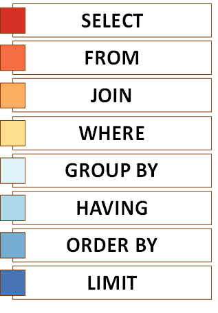

### $\color{dodgerblue}{\textbf{Select}}$

| Goal | Formula | Example |
| --- | --- | --- |
| Select all data | **SELECT** * **FROM** *table name*; | **SELECT** * **FROM** Persons; |
| Select specific data | **SELECT** *column names* **FROM** *table name*; | **SELECT** LastName, FirstName **FROM** Persons; |
| Select distinct cases | **SELECT** **DISTINCT** *column names* **FROM** *table name*; | **SELECT** **DISTINCT** LastName **FROM** Persons |
| Perform a function on the data before returning it: - **AVG**() - **MAX**() - **MIN**() - **SUM**() | **SELECT** **AggFunc**(*column name*) **FROM** *table name*; | **SELECT** **AVG**(Age) **FROM** Persons; |
| Count rows Count non-nulls Count distinct values | **SELECT** **COUNT**() **FROM** *table name*; **SELECT** **COUNT**(*column name*) **FROM** *table name*; **SELECT** **COUNT**(**DISTINCT** *column name*) **FROM** *table name*; | **SELECT** **COUNT**() **FROM** Persons; **SELECT** **COUNT**(Email) **FROM** Persons; **SELECT** **COUNT**(**DISTINCT** LastName) **FROM** Persons; |
| Select element of date | **SELECT** **TimeFunc**(*column name*) **FROM** *table name*; | **SELECT** **MONTH**(Birthday) **FROM** Persons; |

### $\color{dodgerblue}{\textbf{Where}}$

[output not shown]

### $\color{dodgerblue}{\textbf{Order}}$

| Goal | Formula | Example |
| --- | --- | --- |
| Order the result | **SELECT** * **FROM** *table name* **ORDER BY** *column name*; | **SELECT** * **FROM** Persons **ORDER BY** LastName; |
| Ascending and descending | **SELECT** * **FROM** *table name* **ORDER BY** *column name* **ASC**; **SELECT** * **FROM** *table name* **ORDER BY** *column name* **DESC**; | **SELECT** * **FROM** Persons **ORDER BY** Year **DESC**; **SELECT** * **FROM** Persons **ORDER BY** LastName **DESC**, FirstName **ASC**; |

### $\color{dodgerblue}{\textbf{Group}}$

| Goal | Formula | Example |
| --- | --- | --- |
| Aggregate by group | **SELECT** **AggFunc**(*column name 1*), *column name 2* **FROM** *table name* **GROUP BY** *column name 2*; | **SELECT** **AVG**(Age), Team **FROM** Persons **GROUP BY** Team; |
| Filter after grouping | **SELECT** **AggFunc**(*column name 1*), *column name 2* **FROM** *table name* **GROUP BY** *column name 2* **HAVING** *expression*; | **SELECT** **AVG**(Age), Team **FROM** Persons **GROUP BY** Team **HAVING** **AVG**(Age) < 30; |

### $\color{dodgerblue}{\textbf{Naming}}$

| Goal | Formula | Example |
| --- | --- | --- |
| Create a column alias | **SELECT** *column name* **AS** *alias* **FROM** *table name*; | **SELECT** LastName **AS** Family, FirstName **AS** Name **FROM** Persons; |
| Create a table alias | **SELECT** * **FROM** *table name* **AS** *alias*; | **SELECT** * **FROM** Persons **AS** Members; |
| Create masks | **SELECT** * **CASE** **WHEN** *condition 1* **THEN** *result 1* **WHEN** *condition 2* **THEN** *result 2* **ELSE** *result 3* **END** **AS** *alias* **FROM** *table name*; | **SELECT** * **CASE** **WHEN** Age < 18 **THEN** ‘Child’ **WHEN** Age > 65 **THEN** ‘Senior’ **ELSE** ‘Adult’ **END** **AS** AgeGroup **FROM** Persons; |

### $\color{dodgerblue}{\textbf{Joins}}$

Goal

Formula

Example

**SELECT** a.*column1*, b.*column2*  
**FROM** *table1* **AS** a  
_ **JOIN** *table2* as b  
**ON** a.*key* = b.*key*;

**SELECT** a.FirstName, a.LastName, b.PhoneNumber  
**FROM** Persons **AS** a  
**LEFT JOIN** Phonebook as b  
**ON** a.LastName = b.Family;  
**SELECT** a.FirstName, a.LastName, b.PhoneNumber, c.FamilySize  
**FROM** Persons **AS** a  
**INNER JOIN** Phonebook as b  
**ON** a.LastName = b.Family  
**RIGHT JOIN** Census **AS** c  
**ON** b.Address = c.Street;

Using multiple keys

**SELECT** a.*column1*, b.*column2*  
**FROM** *table1* **AS** a  
_ **JOIN** *table2* as b  
**ON** a.*key1* = b.*key1* **AND** a.*key2* = b.*key2*;

**SELECT** a.FirstName, a.LastName, b.PhoneNumber  
**FROM** Persons **AS** a  
**LEFT JOIN** Phonebook as b  
**ON** a.LastName = b.Surname **AND** a.FirstName = b.Name;

Using the same key name

**SELECT** a.*column1*, b.*column2*  
**FROM** *table1* **AS** a  
_ **JOIN** *table2* as b  
**USING** (*key*);

**SELECT** a.FirstName, a.LastName, b.PhoneNumber  
**FROM** Persons **AS** a  
**LEFT JOIN** Phonebook as b  
**USING** (LastName);

### $\color{dodgerblue}{\textbf{Unions}}$

Goal

Formula

Example

Stack frames with the same columns

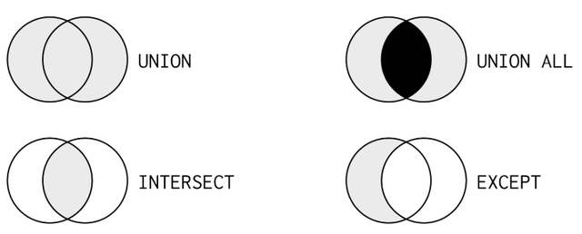

*SQL query 1* **SetFunc** *SQL query 2*;

**SELECT** **DISTINCT** LastName  
**FROM** Members2017  
**UNION**  
**SELECT** **DISTINCT** LastName  
**FROM** Members2018;  
**SELECT** **DISTINCT** LastName  
**FROM** Members2017  
**INTERSECT**  
**SELECT** **DISTINCT** LastName  
**FROM** Members2018;

### $\color{dodgerblue}{\textbf{Subqueries}}$

#### $\color{skyblue}{\textrm{- Inside a WHERE clause}}$

```
SELECT item, stat
  FROM data
 WHERE stat <
       (SELECT AVG(stat)
          FROM data);
```

```r
#Games with more than average goals
SELECT date, home_goal, away_goal
  FROM matches
 WHERE (home_goal + away_goal) >
       (SELECT AVG(home_goal + away_goal)
          FROM matches);
```

| date | home_goal | away_goal |
| --- | --- | --- |
| 2013-12-14 | 6 | 3 |
| 2014-03-22 | 3 | 6 |
| 2013-10-30 | 7 | 3 |

```
SELECT *
  FROM dataset1
 WHERE item IN
       (SELECT item
        FROM dataset2);
```

```r
#Teams without a home game
SELECT team_name
  FROM teams
 WHERE team_id NOT IN
       (SELECT DISTINCT hometeam_id
          FROM matches);
```

| team_long_name |
| --- |
| FCV Dender EH |
| KSV Roeselare |
| Tubize |

#### $\color{skyblue}{\textrm{- Inside a FROM Clause}}$

```
    SELECT *
      FROM (SELECT key, a.col1, b.col2, derivedcol
              FROM dataset1 AS a
INNER JOIN dataset2 AS b
           USING (key))
     WHERE derivedcol > value
```

```r
#Number of high scoring matches per country
    SELECT c.name AS country_name, COUNT(m.id) AS matches
      FROM country as c
INNER JOIN (SELECT country_id, id
              FROM matches_2013_2014
             WHERE (home_goal + away_goal) >= 10)
                AS m
        ON c.id = m.country_id
  GROUP BY country_name;
```

| country_name | matches |
| --- | --- |
| Spain | 4 |
| England | 3 |
| Germany | 1 |

#### $\color{skyblue}{\textrm{- Inside a SELECT Clause}}$

```
SELECT item,
  (SELECT derviedcol
     FROM dataset2) AS derivedcol
  FROM dataset1;
```

```r
#Comparing team average to overall average
  SELECT country,
         AVG(home_goal + away_goal) AS avg_goals,
         AVG(home_goal + away_goal) - (SELECT AVG(home_goal + away_goal
                                         FROM matches)) AS diff
    FROM matches
GROUP BY country;
```

| country | avg_goals | diff |
| --- | --- | --- |
| Switzerland | 2.89 | 0.12 |
| Poland | 2.64 | -0.13 |
| Netherlands | 3.20 | 0.43 |

#### $\color{skyblue}{\textrm{- Aliased}}$

```
WITH alias AS(
  SELECT item, derivedcol
    FROM dataset)

SELECT derivedcol
  FROM alias;
```

```r
#Comparing team average to overall average
WITH overall_avg AS(
  SELECT season, AVG(home_goal + away_goal) AS overall_avg
    FROM matches)

   SELECT m.country,
          AVG(m.home_goal + m.away_goal) AS avg_goals,
          AVG(m.home_goal + m.away_goal) - o.overall_avg AS diff
     FROM matches AS m
LEFT JOIN overall_avg as o
          USING (season)
 GROUP BY m.country;
```

| country | avg_goals | diff |
| --- | --- | --- |
| Switzerland | 2.89 | 0.12 |
| Poland | 2.64 | -0.13 |
| Netherlands | 3.20 | 0.43 |

# $\color{darkblue}{\textbf{Advanced Querying}}$

### $\color{dodgerblue}{\textbf{Window Functions}}$

#### $\color{skyblue}{\textrm{- Over}}$

```r
#Overall average goals
SELECT match_id, date, goals,
       AVG(goals) OVER() AS overall_avg_goals
  FROM matches;
```

| match_id | date | goals | overall_avg_goals |
| --- | --- | --- | --- |
| 757 | 2011-07-29 | 3 | 2.75 |
| 758 | 2011-07-30 | 2 | 2.75 |
| 759 | 2011-07-30 | 4 | 2.75 |
| 760 | 2011-07-30 | 2 | 2.75 |

```r
#Overall and season average goals
SELECT match_id, season, goals,
       AVG(goals) OVER() AS overall_avg_goals,
       AVG(goals) OVER(PARTITION BY season) AS season_avg_goals
  FROM matches;
```

| match_id | season | goals | overall_avg_goals | season_avg_goals |
| --- | --- | --- | --- | --- |
| 1382 | 2012-2013 | 3 | 2.5 | 2 |
| 758 | 2011-2012 | 2 | 2.5 | 3 |
| 759 | 2011-2012 | 4 | 2.5 | 3 |
| 1393 | 2012-2013 | 1 | 2.5 | 2 |

#### $\color{skyblue}{\textrm{- Rank}}$

```r
#Rank by number of goals
SELECT match_id, date, goals,
       RANK() OVER(ORDER BY goals DESC) AS goal_rank
  FROM matches;
```

| match_id | date | goals | goal_rank |
| --- | --- | --- | --- |
| 757 | 2011-07-29 | 3 | 2 |
| 758 | 2011-07-30 | 2 | 3 |
| 759 | 2011-07-30 | 4 | 1 |
| 760 | 2011-07-30 | 2 | 3 |

```r
#Rank by average number of goals
  SELECT league, AVG(goals) AS avg_goals,
         RANK() OVER(ORDER BY AVG(goals) DESC) AS league_rank
    FROM matches
GROUP BY league;
```

| league | avg_goals | league_rank |
| --- | --- | --- |
| Belgium Jupiler League | 2.879 | 2 |
| England Premier League | 2.801 | 3 |
| Netherlands Eredivisie | 3.258 | 1 |

#### $\color{skyblue}{\textrm{- Sliding Window}}$

```r
#Running total and average
SELECT match_id, date, goals,
       SUM(goals) OVER(ORDER BY date)
          ROWS BETWEEN UNBOUNDED PRECEDING AND CURRENT ROW) AS running_total,
       AVG(goals) OVER(ORDER BY date)
          ROWS BETWEEN UNBOUNDED PRECEDING AND CURRENT ROW) AS running_avg
  FROM matches;
```

| match_id | date | goals | running_total | running_avg |
| --- | --- | --- | --- | --- |
| 757 | 2011-07-29 | 3 | 3 | 3 |
| 758 | 2011-07-30 | 2 | 5 | 2.5 |
| 759 | 2011-07-30 | 4 | 9 | 3 |
| 760 | 2011-07-30 | 2 | 11 | 2.75 |

```r
#Total and average based on set rows
SELECT match_id, date, goals,
       SUM(goals) OVER(ORDER BY date)
          ROWS BETWEEN 2 PRECEDING AND CURRENT ROW) AS three_match_total,
       AVG(goals) OVER(ORDER BY date)
          ROWS BETWEEN 2 PRECEDING AND CURRENT ROW) AS three_match_avg
  FROM matches;
```

| match_id | date | goals | three_match_total | three_match_avg |
| --- | --- | --- | --- | --- |
| 757 | 2011-07-29 | 3 | 3 | 3 |
| 758 | 2011-07-30 | 2 | 5 | 2.5 |
| 759 | 2011-07-30 | 4 | 9 | 3 |
| 760 | 2011-07-30 | 2 | 8 | 2.667 |

### $\color{dodgerblue}{\textbf{Count a Case When}}$

```r
SELECT user_id,
       COUNT(CASE WHEN message LIKE '%!%' THEN 'Excited Tweet' END) as 'Excited',
       COUNT(CASE WHEN message LIKE '%?%' THEN 'Question' END) as 'Question'
  FROM comments
 GROUP BY user_id;
```

| user_id | Excited | Question |
| --- | --- | --- |
| 1 | 2 | 0 |
| 2 | 0 | 0 |
| 3 | 0 | 1 |
| 4 | 1 | 0 |
| 5 | 0 | 0 |
| 6 | 2 | 0 |
| 7 | 2 | 0 |

```r
  SELECT tweat_id,
         ROUND(AVG(CASE WHEN message LIKE '%!%' THEN 1 ELSE 0 END), 2) as 'Excited',
         ROUND(AVG(CASE WHEN message LIKE '%?%' THEN 1 ELSE 0 END), 2) as 'Question'
    FROM comments
GROUP BY tweat_id;
```

| tweat_id | Excited | Question |
| --- | --- | --- |
| 49 | 0.33 | 0.33 |
| 75 | 1.00 | 0.00 |
| 77 | 0.50 | 0.00 |
| 87 | 1.00 | 0.00 |
| 88 | 0.50 | 0.00 |

# $\color{darkblue}{\textbf{Holywell's SQL style guide}}$

### $\color{dodgerblue}{\textbf{Overview}}$

These guidelines are designed to be compatible with Joe Celko’s *SQL Programming Style* book to make adoption for teams who have already read that book easier. This guide is a little more opinionated in some areas and in others a little more relaxed. It is certainly more succinct where Celko’s book contains anecdotes and reasoning behind each rule as thoughtful prose.

SQL style guide by Simon Holywell is licensed under a Creative Commons Attribution-ShareAlike 4.0 International License. Based on a work at http://www.sqlstyle.guide.

### $\color{dodgerblue}{\textbf{General}}$

#### $\color{skyblue}{\textrm{- Do}}$

- Use consistent and descriptive identifiers and names.
- Make judicious use of white space and indentation to make code easier to read.
- Store ISO-8601 compliant time and date information (`YYYY-MM-DD HH:MM:SS.SSSSS`).
- Try to use only standard SQL functions instead of vendor specific functions for reasons of portability.
- Keep code succinct and devoid of redundant SQL—such as unnecessary quoting or parentheses or `WHERE` clauses that can otherwise be derived.
- Include comments in SQL code where necessary. Use the C style opening `/*` and closing `*/` where possible otherwise precede comments with `--` and finish them with a new line.

```sql
SELECT file_hash  -- stored ssdeep hash
  FROM file_system
 WHERE file_name = '.vimrc';
```

```sql
/* Updating the file record after writing to the file */
UPDATE file_system
   SET file_modified_date = '1980-02-22 13:19:01.00000',
       file_size = 209732
 WHERE file_name = '.vimrc';
```

#### $\color{skyblue}{\textrm{- Avoid}}$

- CamelCase—it is difficult to scan quickly.
- Descriptive prefixes or Hungarian notation such as `sp_` or `tbl`.
- Plurals—use the more natural collective term where possible instead. For example `staff` instead of `employees` or `people` instead of `individuals`.
- Quoted identifiers—if you must use them then stick to SQL92 double quotes for portability (you may need to configure your SQL server to support this depending on vendor).
- Object oriented design principles should not be applied to SQL or database structures.

### $\color{dodgerblue}{\textbf{Naming conventions}}$

#### $\color{skyblue}{\textrm{- General}}$

- Ensure the name is unique and does not exist as a reserved keyword.
- Keep the length to a maximum of 30 bytes—in practice this is 30 characters unless you are using multi-byte character set.
- Names must begin with a letter and may not end with an underscore.
- Only use letters, numbers, and underscores in names.
- Avoid the use of multiple consecutive underscores—these can be hard to read.
- Use underscores where you would naturally include a space in the name (first name becomes `first_name`).
- Avoid abbreviations and if you have to use them make sure they are commonly understood.

```sql
SELECT first_name
  FROM staff;
```

#### $\color{skyblue}{\textrm{- Tables}}$

- Use a collective name or, less ideally, a plural form. For example (in order of preference) `staff` and `employees`.
- Do not prefix with `tbl` or any other such descriptive prefix or Hungarian notation.
- Never give a table the same name as one of its columns and vice versa.
- Avoid, where possible, concatenating two table names together to create the name of a relationship table. Rather than `cars_mechanics` prefer `services`.

#### $\color{skyblue}{\textrm{- Columns}}$

- Always use the singular name.
- Where possible avoid simply using `id` as the primary identifier for the table.
- Do not add a column with the same name as its table and vice versa.
- Always use lowercase except where it may make sense not to, such as proper nouns.

#### $\color{skyblue}{\textrm{- Aliasing or Correlations}}$

- Should relate in some way to the object or expression they are aliasing.
- As a rule of thumb the correlation name should be the first letter of each word in the object’s name.
- If there is already a correlation with the same name then append a number.
- Always include the `AS` keyword—makes it easier to read as it is explicit.
- For computed data (`SUM()` or `AVG()`) use the name you would give it were it a column defined in the schema.

```sql
SELECT first_name AS fn
  FROM staff AS s1
  JOIN students AS s2
    ON s2.mentor_id = s1.staff_num;
```

```sql
SELECT SUM(s.monitor_tally) AS monitor_total
  FROM staff AS s;
```

#### $\color{skyblue}{\textrm{- Stored Procedures}}$

- The name must contain a verb.
- Do not prefix with `sp_` or any other such descriptive prefix or Hungarian notation.

#### $\color{skyblue}{\textrm{- Uniform Suffixed}}$

The following suffixes have a universal meaning ensuring the columns can be read and understood easily from SQL code. Use the correct suffix where appropriate.

- `_id`—a unique identifier such as a column that is a primary key.
- `_status`—flag value or some other status of any type such as `publication_status`.
- `_total`—the total or sum of a collection of values.
- `_num`—denotes the field contains any kind of number.
- `_name`—signifies a name such as `first_name`.
- `_seq`—contains a contiguous sequence of values.
- `_date`—denotes a column that contains the date of something.
- `_tally`—a count.
- `_size`—the size of something such as a file size or clothing.
- `_addr`—an address for the record could be physical or intangible such as `ip_addr`.

### $\color{dodgerblue}{\textbf{Query syntax}}$

#### $\color{skyblue}{\textrm{- Reserved Words}}$

Always use uppercase for the reserved keywords like `SELECT` and `WHERE`.

It is best to avoid the abbreviated keywords and use the full length ones where available (prefer `ABSOLUTE` to `ABS`).

Do not use database server specific keywords where an ANSI SQL keyword already exists performing the same function. This helps to make code more portable.

```sql
SELECT model_num
  FROM phones AS p
 WHERE p.release_date > '2014-09-30';
```

#### $\color{skyblue}{\textrm{- White Space}}$

To make the code easier to read it is important that the correct complement of spacing is used. Do not crowd code or remove natural language spaces.

*Spaces*

Spaces should be used to line up the code so that the root keywords all end on the same character boundary. This forms a river down the middle making it easy for the readers eye to scan over the code and separate the keywords from the implementation detail. Rivers are bad in typography, but helpful here.

```sql
(SELECT f.species_name,
        AVG(f.height) AS average_height, AVG(f.diameter) AS average_diameter
   FROM flora AS f
  WHERE f.species_name = 'Banksia'
     OR f.species_name = 'Sheoak'
     OR f.species_name = 'Wattle'
  GROUP BY f.species_name, f.observation_date)

  UNION ALL

(SELECT b.species_name,
        AVG(b.height) AS average_height, AVG(b.diameter) AS average_diameter
   FROM botanic_garden_flora AS b
  WHERE b.species_name = 'Banksia'
     OR b.species_name = 'Sheoak'
     OR b.species_name = 'Wattle'
  GROUP BY b.species_name, b.observation_date);
```

Notice that `SELECT`, `FROM`, etc. are all right aligned while the actual column names and implementation specific details are left aligned.

Although not exhaustive always include spaces:

- before and after equals (`=`)
- after commas (`,`)
- surrounding apostrophes (`'`) where not within parentheses or with a trailing comma or semicolon.

```sql
SELECT a.title, a.release_date, a.recording_date
  FROM albums AS a
 WHERE a.title = 'Charcoal Lane'
    OR a.title = 'The New Danger';
```

*Line spacing*

Always include newlines/vertical space:

- before `AND` or `OR`
- after semicolons to separate queries for easier reading
- after each keyword definition
- after a comma when separating multiple columns into logical groups
- to separate code into related sections, which helps to ease the readability of large chunks of code.

Keeping all the keywords aligned to the righthand side and the values left aligned creates a uniform gap down the middle of query. It makes it much easier to scan the query definition over quickly too.

```sql
INSERT INTO albums (title, release_date, recording_date)
VALUES ('Charcoal Lane', '1990-01-01 01:01:01.00000', '1990-01-01 01:01:01.00000'),
       ('The New Danger', '2008-01-01 01:01:01.00000', '1990-01-01 01:01:01.00000');
```

```sql
UPDATE albums
   SET release_date = '1990-01-01 01:01:01.00000'
 WHERE title = 'The New Danger';
```

```sql
SELECT a.title,
       a.release_date, a.recording_date, a.production_date -- grouped dates together
  FROM albums AS a
 WHERE a.title = 'Charcoal Lane'
    OR a.title = 'The New Danger';
```

#### $\color{skyblue}{\textrm{- Indentation}}$

To ensure that SQL is readable it is important that standards of indentation are followed.

*Joins*

Joins should be indented to the other side of the river and grouped with a new line where necessary.

```sql
SELECT r.last_name
  FROM riders AS r
       INNER JOIN bikes AS b
       ON r.bike_vin_num = b.vin_num
          AND b.engine_tally > 2

       INNER JOIN crew AS c
       ON r.crew_chief_last_name = c.last_name
          AND c.chief = 'Y';
```

*Subqueries*

Subqueries should also be aligned to the right side of the river and then laid out using the same style as any other query. Sometimes it will make sense to have the closing parenthesis on a new line at the same character position as its opening partner—this is especially true where you have nested subqueries.

```sql
SELECT r.last_name,
       (SELECT MAX(YEAR(championship_date))
          FROM champions AS c
         WHERE c.last_name = r.last_name
           AND c.confirmed = 'Y') AS last_championship_year
  FROM riders AS r
 WHERE r.last_name IN
       (SELECT c.last_name
          FROM champions AS c
         WHERE YEAR(championship_date) > '2008'
           AND c.confirmed = 'Y');
```

#### $\color{skyblue}{\textrm{- Preferred Formalisms}}$

- Make use of `BETWEEN` where possible instead of combining multiple statements with `AND`.
- Similarly use `IN()` instead of multiple `OR` clauses.
- Where a value needs to be interpreted before leaving the database use the `CASE` expression. `CASE` statements can be nested to form more complex logical structures.
- Avoid the use of `UNION` clauses and temporary tables where possible. If the schema can be optimised to remove the reliance on these features then it most likely should be.

```sql
SELECT CASE postcode
       WHEN 'BN1' THEN 'Brighton'
       WHEN 'EH1' THEN 'Edinburgh'
       END AS city
  FROM office_locations
 WHERE country = 'United Kingdom'
   AND opening_time BETWEEN 8 AND 9
   AND postcode IN ('EH1', 'BN1', 'NN1', 'KW1');
```

### $\color{dodgerblue}{\textbf{Create syntax}}$

When declaring schema information it is also important to maintain human readable code. To facilitate this ensure the column definitions are ordered and grouped where it makes sense to do so.

Indent column definitions by four (4) spaces within the `CREATE` definition.

#### $\color{skyblue}{\textrm{- Choosing data types}}$

- Where possible do not use vendor specific data types—these are not portable and may not be available in older versions of the same vendor’s software.
- Only use `REAL` or `FLOAT` types where it is strictly necessary for floating point mathematics otherwise prefer `NUMERIC` and `DECIMAL` at all times. Floating point rounding errors are a nuisance!

#### $\color{skyblue}{\textrm{- Specifying default values}}$

- The default value must be the same type as the column—if a column is declared a `DECIMAL` do not provide an `INTEGER` default value.
- Default values must follow the data type declaration and come before any `NOT NULL` statement.

#### $\color{skyblue}{\textrm{- Constraints and Keys}}$

Constraints and their subset, keys, are a very important component of any database definition. They can quickly become very difficult to read and reason about though so it is important that a standard set of guidelines are followed.

*Choosing keys*

Deciding the column(s) that will form the keys in the definition should be a carefully considered activity as it will effect performance and data integrity.

1. The key should be unique to some degree.
2. Consistency in terms of data type for the value across the schema and a lower likelihood of this changing in the future.
3. Can the value be validated against a standard format (such as one published by ISO)? Encouraging conformity to point 2.
4. Keeping the key as simple as possible whilst not being scared to use compound keys where necessary.

It is a reasoned and considered balancing act to be performed at the definition of a database. Should requirements evolve in the future it is possible to make changes to the definitions to keep them up to date.

*Defining constraints*

Once the keys are decided it is possible to define them in the system using constraints along with field value validation.

General

- Tables must have at least one key to be complete and useful.
- Constraints should be given a custom name excepting `UNIQUE`, `PRIMARY KEY` and `FOREIGN KEY` where the database vendor will generally supply sufficiently intelligible names automatically.

Layout and order

- Specify the primary key first right after the `CREATE TABLE` statement.
- Constraints should be defined directly beneath the column they correspond to. Indent the constraint so that it aligns to the right of the column name.
- If it is a multi-column constraint then consider putting it as close to both column definitions as possible and where this is difficult as a last resort include them at the end of the `CREATE TABLE` definition.
- If it is a table level constraint that applies to the entire table then it should also appear at the end.
- Use alphabetical order where `ON DELETE` comes before `ON UPDATE`.
- If it make senses to do so align each aspect of the query on the same character position. For example all `NOT NULL` definitions could start at the same character position. This is not hard and fast, but it certainly makes the code much easier to scan and read.

Validation

- Use `LIKE` and `SIMILAR TO` constraints to ensure the integrity of strings where the format is known.
- Where the ultimate range of a numerical value is known it must be written as a range `CHECK()` to prevent incorrect values entering the database or the silent truncation of data too large to fit the column definition. In the least it should check that the value is greater than zero in most cases.
- `CHECK()` constraints should be kept in separate clauses to ease debugging.

```sql
CREATE TABLE staff (
    PRIMARY KEY (staff_num),
    staff_num      INT(5)       NOT NULL,
    first_name     VARCHAR(100) NOT NULL,
    pens_in_drawer INT(2)       NOT NULL,
                   CONSTRAINT pens_in_drawer_range
                   CHECK(pens_in_drawer >= 1 AND pens_in_drawer < 100)
);
```

#### $\color{skyblue}{\textrm{- Designs to Avoid}}$

- Object oriented design principles do not effectively translate to relational database designs—avoid this pitfall.
- Placing the value in one column and the units in another column. The column should make the units self evident to prevent the requirement to combine columns again later in the application. Use `CHECK()` to ensure valid data is inserted into the column.
- [EAV (Entity Attribute Value)](https://en.wikipedia.org/wiki/Entity%E2%80%93attribute%E2%80%93value_model) tables—use a specialist product intended for handling such schema-less data instead.
- Splitting up data that should be in one table across many because of arbitrary concerns such as time-based archiving or location in a multi-national organisation. Later queries must then work across multiple tables with `UNION` rather than just simply querying one table.

### $\color{dodgerblue}{\textbf{Appendix}}$

#### $\color{skyblue}{\textrm{- Reserved Keyword Reference}}$

A list of ANSI SQL (92, 99 and 2003), MySQL 3 to 5.x, PostgreSQL 8.1, MS SQL Server 2000, MS ODBC and Oracle 10.2 reserved keywords.

```sql
A
ABORT
ABS
ABSOLUTE
ACCESS
ACTION
ADA
ADD
ADMIN
AFTER
AGGREGATE
ALIAS
ALL
ALLOCATE
ALSO
ALTER
ALWAYS
ANALYSE
ANALYZE
AND
ANY
ARE
ARRAY
AS
ASC
ASENSITIVE
ASSERTION
ASSIGNMENT
ASYMMETRIC
AT
ATOMIC
ATTRIBUTE
ATTRIBUTES
AUDIT
AUTHORIZATION
AUTO_INCREMENT
AVG
AVG_ROW_LENGTH
BACKUP
BACKWARD
BEFORE
BEGIN
BERNOULLI
BETWEEN
BIGINT
BINARY
BIT
BIT_LENGTH
BITVAR
BLOB
BOOL
BOOLEAN
BOTH
BREADTH
BREAK
BROWSE
BULK
BY
C
CACHE
CALL
CALLED
CARDINALITY
CASCADE
CASCADED
CASE
CAST
CATALOG
CATALOG_NAME
CEIL
CEILING
CHAIN
CHANGE
CHAR
CHAR_LENGTH
CHARACTER
CHARACTER_LENGTH
CHARACTER_SET_CATALOG
CHARACTER_SET_NAME
CHARACTER_SET_SCHEMA
CHARACTERISTICS
CHARACTERS
CHECK
CHECKED
CHECKPOINT
CHECKSUM
CLASS
CLASS_ORIGIN
CLOB
CLOSE
CLUSTER
CLUSTERED
COALESCE
COBOL
COLLATE
COLLATION
COLLATION_CATALOG
COLLATION_NAME
COLLATION_SCHEMA
COLLECT
COLUMN
COLUMN_NAME
COLUMNS
COMMAND_FUNCTION
COMMAND_FUNCTION_CODE
COMMENT
COMMIT
COMMITTED
COMPLETION
COMPRESS
COMPUTE
CONDITION
CONDITION_NUMBER
CONNECT
CONNECTION
CONNECTION_NAME
CONSTRAINT
CONSTRAINT_CATALOG
CONSTRAINT_NAME
CONSTRAINT_SCHEMA
CONSTRAINTS
CONSTRUCTOR
CONTAINS
CONTAINSTABLE
CONTINUE
CONVERSION
CONVERT
COPY
CORR
CORRESPONDING
COUNT
COVAR_POP
COVAR_SAMP
CREATE
CREATEDB
CREATEROLE
CREATEUSER
CROSS
CSV
CUBE
CUME_DIST
CURRENT
CURRENT_DATE
CURRENT_DEFAULT_TRANSFORM_GROUP
CURRENT_PATH
CURRENT_ROLE
CURRENT_TIME
CURRENT_TIMESTAMP
CURRENT_TRANSFORM_GROUP_FOR_TYPE
CURRENT_USER
CURSOR
CURSOR_NAME
CYCLE
DATA
DATABASE
DATABASES
DATE
DATETIME
DATETIME_INTERVAL_CODE
DATETIME_INTERVAL_PRECISION
DAY
DAY_HOUR
DAY_MICROSECOND
DAY_MINUTE
DAY_SECOND
DAYOFMONTH
DAYOFWEEK
DAYOFYEAR
DBCC
DEALLOCATE
DEC
DECIMAL
DECLARE
DEFAULT
DEFAULTS
DEFERRABLE
DEFERRED
DEFINED
DEFINER
DEGREE
DELAY_KEY_WRITE
DELAYED
DELETE
DELIMITER
DELIMITERS
DENSE_RANK
DENY
DEPTH
DEREF
DERIVED
DESC
DESCRIBE
DESCRIPTOR
DESTROY
DESTRUCTOR
DETERMINISTIC
DIAGNOSTICS
DICTIONARY
DISABLE
DISCONNECT
DISK
DISPATCH
DISTINCT
DISTINCTROW
DISTRIBUTED
DIV
DO
DOMAIN
DOUBLE
DROP
DUAL
DUMMY
DUMP
DYNAMIC
DYNAMIC_FUNCTION
DYNAMIC_FUNCTION_CODE
EACH
ELEMENT
ELSE
ELSEIF
ENABLE
ENCLOSED
ENCODING
ENCRYPTED
END
END-EXEC
ENUM
EQUALS
ERRLVL
ESCAPE
ESCAPED
EVERY
EXCEPT
EXCEPTION
EXCLUDE
EXCLUDING
EXCLUSIVE
EXEC
EXECUTE
EXISTING
EXISTS
EXIT
EXP
EXPLAIN
EXTERNAL
EXTRACT
FALSE
FETCH
FIELDS
FILE
FILLFACTOR
FILTER
FINAL
FIRST
FLOAT
FLOAT4
FLOAT8
FLOOR
FLUSH
FOLLOWING
FOR
FORCE
FOREIGN
FORTRAN
FORWARD
FOUND
FREE
FREETEXT
FREETEXTTABLE
FREEZE
FROM
FULL
FULLTEXT
FUNCTION
FUSION
G
GENERAL
GENERATED
GET
GLOBAL
GO
GOTO
GRANT
GRANTED
GRANTS
GREATEST
GROUP
GROUPING
HANDLER
HAVING
HEADER
HEAP
HIERARCHY
HIGH_PRIORITY
HOLD
HOLDLOCK
HOST
HOSTS
HOUR
HOUR_MICROSECOND
HOUR_MINUTE
HOUR_SECOND
IDENTIFIED
IDENTITY
IDENTITY_INSERT
IDENTITYCOL
IF
IGNORE
ILIKE
IMMEDIATE
IMMUTABLE
IMPLEMENTATION
IMPLICIT
IN
INCLUDE
INCLUDING
INCREMENT
INDEX
INDICATOR
INFILE
INFIX
INHERIT
INHERITS
INITIAL
INITIALIZE
INITIALLY
INNER
INOUT
INPUT
INSENSITIVE
INSERT
INSERT_ID
INSTANCE
INSTANTIABLE
INSTEAD
INT
INT1
INT2
INT3
INT4
INT8
INTEGER
INTERSECT
INTERSECTION
INTERVAL
INTO
INVOKER
IS
ISAM
ISNULL
ISOLATION
ITERATE
JOIN
K
KEY
KEY_MEMBER
KEY_TYPE
KEYS
KILL
LANCOMPILER
LANGUAGE
LARGE
LAST
LAST_INSERT_ID
LATERAL
LEADING
LEAST
LEAVE
LEFT
LENGTH
LESS
LEVEL
LIKE
LIMIT
LINENO
LINES
LISTEN
LN
LOAD
LOCAL
LOCALTIME
LOCALTIMESTAMP
LOCATION
LOCATOR
LOCK
LOGIN
LOGS
LONG
LONGBLOB
LONGTEXT
LOOP
LOW_PRIORITY
LOWER
M
MAP
MATCH
MATCHED
MAX
MAX_ROWS
MAXEXTENTS
MAXVALUE
MEDIUMBLOB
MEDIUMINT
MEDIUMTEXT
MEMBER
MERGE
MESSAGE_LENGTH
MESSAGE_OCTET_LENGTH
MESSAGE_TEXT
METHOD
MIDDLEINT
MIN
MIN_ROWS
MINUS
MINUTE
MINUTE_MICROSECOND
MINUTE_SECOND
MINVALUE
MLSLABEL
MOD
MODE
MODIFIES
MODIFY
MODULE
MONTH
MONTHNAME
MORE
MOVE
MULTISET
MUMPS
MYISAM
NAME
NAMES
NATIONAL
NATURAL
NCHAR
NCLOB
NESTING
NEW
NEXT
NO
NO_WRITE_TO_BINLOG
NOAUDIT
NOCHECK
NOCOMPRESS
NOCREATEDB
NOCREATEROLE
NOCREATEUSER
NOINHERIT
NOLOGIN
NONCLUSTERED
NONE
NORMALIZE
NORMALIZED
NOSUPERUSER
NOT
NOTHING
NOTIFY
NOTNULL
NOWAIT
NULL
NULLABLE
NULLIF
NULLS
NUMBER
NUMERIC
OBJECT
OCTET_LENGTH
OCTETS
OF
OFF
OFFLINE
OFFSET
OFFSETS
OIDS
OLD
ON
ONLINE
ONLY
OPEN
OPENDATASOURCE
OPENQUERY
OPENROWSET
OPENXML
OPERATION
OPERATOR
OPTIMIZE
OPTION
OPTIONALLY
OPTIONS
OR
ORDER
ORDERING
ORDINALITY
OTHERS
OUT
OUTER
OUTFILE
OUTPUT
OVER
OVERLAPS
OVERLAY
OVERRIDING
OWNER
PACK_KEYS
PAD
PARAMETER
PARAMETER_MODE
PARAMETER_NAME
PARAMETER_ORDINAL_POSITION
PARAMETER_SPECIFIC_CATALOG
PARAMETER_SPECIFIC_NAME
PARAMETER_SPECIFIC_SCHEMA
PARAMETERS
PARTIAL
PARTITION
PASCAL
PASSWORD
PATH
PCTFREE
PERCENT
PERCENT_RANK
PERCENTILE_CONT
PERCENTILE_DISC
PLACING
PLAN
PLI
POSITION
POSTFIX
POWER
PRECEDING
PRECISION
PREFIX
PREORDER
PREPARE
PREPARED
PRESERVE
PRIMARY
PRINT
PRIOR
PRIVILEGES
PROC
PROCEDURAL
PROCEDURE
PROCESS
PROCESSLIST
PUBLIC
PURGE
QUOTE
RAID0
RAISERROR
RANGE
RANK
RAW
READ
READS
READTEXT
REAL
RECHECK
RECONFIGURE
RECURSIVE
REF
REFERENCES
REFERENCING
REGEXP
REGR_AVGX
REGR_AVGY
REGR_COUNT
REGR_INTERCEPT
REGR_R2
REGR_SLOPE
REGR_SXX
REGR_SXY
REGR_SYY
REINDEX
RELATIVE
RELEASE
RELOAD
RENAME
REPEAT
REPEATABLE
REPLACE
REPLICATION
REQUIRE
RESET
RESIGNAL
RESOURCE
RESTART
RESTORE
RESTRICT
RESULT
RETURN
RETURNED_CARDINALITY
RETURNED_LENGTH
RETURNED_OCTET_LENGTH
RETURNED_SQLSTATE
RETURNS
REVOKE
RIGHT
RLIKE
ROLE
ROLLBACK
ROLLUP
ROUTINE
ROUTINE_CATALOG
ROUTINE_NAME
ROUTINE_SCHEMA
ROW
ROW_COUNT
ROW_NUMBER
ROWCOUNT
ROWGUIDCOL
ROWID
ROWNUM
ROWS
RULE
SAVE
SAVEPOINT
SCALE
SCHEMA
SCHEMA_NAME
SCHEMAS
SCOPE
SCOPE_CATALOG
SCOPE_NAME
SCOPE_SCHEMA
SCROLL
SEARCH
SECOND
SECOND_MICROSECOND
SECTION
SECURITY
SELECT
SELF
SENSITIVE
SEPARATOR
SEQUENCE
SERIALIZABLE
SERVER_NAME
SESSION
SESSION_USER
SET
SETOF
SETS
SETUSER
SHARE
SHOW
SHUTDOWN
SIGNAL
SIMILAR
SIMPLE
SIZE
SMALLINT
SOME
SONAME
SOURCE
SPACE
SPATIAL
SPECIFIC
SPECIFIC_NAME
SPECIFICTYPE
SQL
SQL_BIG_RESULT
SQL_BIG_SELECTS
SQL_BIG_TABLES
SQL_CALC_FOUND_ROWS
SQL_LOG_OFF
SQL_LOG_UPDATE
SQL_LOW_PRIORITY_UPDATES
SQL_SELECT_LIMIT
SQL_SMALL_RESULT
SQL_WARNINGS
SQLCA
SQLCODE
SQLERROR
SQLEXCEPTION
SQLSTATE
SQLWARNING
SQRT
SSL
STABLE
START
STARTING
STATE
STATEMENT
STATIC
STATISTICS
STATUS
STDDEV_POP
STDDEV_SAMP
STDIN
STDOUT
STORAGE
STRAIGHT_JOIN
STRICT
STRING
STRUCTURE
STYLE
SUBCLASS_ORIGIN
SUBLIST
SUBMULTISET
SUBSTRING
SUCCESSFUL
SUM
SUPERUSER
SYMMETRIC
SYNONYM
SYSDATE
SYSID
SYSTEM
SYSTEM_USER
TABLE
TABLE_NAME
TABLES
TABLESAMPLE
TABLESPACE
TEMP
TEMPLATE
TEMPORARY
TERMINATE
TERMINATED
TEXT
TEXTSIZE
THAN
THEN
TIES
TIME
TIMESTAMP
TIMEZONE_HOUR
TIMEZONE_MINUTE
TINYBLOB
TINYINT
TINYTEXT
TO
TOAST
TOP
TOP_LEVEL_COUNT
TRAILING
TRAN
TRANSACTION
TRANSACTION_ACTIVE
TRANSACTIONS_COMMITTED
TRANSACTIONS_ROLLED_BACK
TRANSFORM
TRANSFORMS
TRANSLATE
TRANSLATION
TREAT
TRIGGER
TRIGGER_CATALOG
TRIGGER_NAME
TRIGGER_SCHEMA
TRIM
TRUE
TRUNCATE
TRUSTED
TSEQUAL
TYPE
UESCAPE
UID
UNBOUNDED
UNCOMMITTED
UNDER
UNDO
UNENCRYPTED
UNION
UNIQUE
UNKNOWN
UNLISTEN
UNLOCK
UNNAMED
UNNEST
UNSIGNED
UNTIL
UPDATE
UPDATETEXT
UPPER
USAGE
USE
USER
USER_DEFINED_TYPE_CATALOG
USER_DEFINED_TYPE_CODE
USER_DEFINED_TYPE_NAME
USER_DEFINED_TYPE_SCHEMA
USING
UTC_DATE
UTC_TIME
UTC_TIMESTAMP
VACUUM
VALID
VALIDATE
VALIDATOR
VALUE
VALUES
VAR_POP
VAR_SAMP
VARBINARY
VARCHAR
VARCHAR2
VARCHARACTER
VARIABLE
VARIABLES
VARYING
VERBOSE
VIEW
VOLATILE
WAITFOR
WHEN
WHENEVER
WHERE
WHILE
WIDTH_BUCKET
WINDOW
WITH
WITHIN
WITHOUT
WORK
WRITE
WRITETEXT
X509
XOR
YEAR
YEAR_MONTH
ZEROFILL
ZONE
```

#### $\color{skyblue}{\textrm{- Column Data Types}}$

These are some suggested column data types to use for maximum compatibility between database engines.

Character types:

- CHAR
- CLOB
- VARCHAR

Numeric types

- Exact numeric types
  - BIGINT
  - DECIMAL
  - DECFLOAT
  - INTEGER
  - NUMERIC
  - SMALLINT
- Approximate numeric types
  - DOUBLE PRECISION
  - FLOAT
  - REAL

Datetime types

- DATE
- TIME
- TIMESTAMP

Binary types:

- BINARY
- BLOB
- VARBINARY

Additional types

- Boolean
- INTERVAL
- XML